# Flipping tibbles for many models

espnscrapeR

NFL

tidyverse

tidymodels

Pivoting data from wide to long to run many models at once

Thomas Mock  
05-01-2020

# Many Models

The `tidymodels` package advocates for a nest-map-unnest workflow for running many models at once. While this typically is used for some type of group as seen in the [`tidymodels` docs](https://www.tidymodels.org/learn/statistics/tidy-analysis/#regression-models), we can also do it for running many models at once from a wide dataset.

Our goal is to get all of the measures into a `long` form tibble so that we can fit all of the models at once, and plot it all at once.

## Basic Example

This basic example is borrowed directly from the [`tidymodels` docs](https://www.tidymodels.org/learn/statistics/tidy-analysis/#regression-models).

First you nest the data by a grouping variable to get list-columns of each split data/tibble.

```
mtcars <- as_tibble(mtcars)  # to play nicely with list-cols

nest_mtcars <- mtcars %>%
  nest(data = c(-am))

nest_mtcars
```

```
# A tibble: 2 x 2
     am data
  <dbl> <list>
1     1 <tibble [13 × 10]>
2     0 <tibble [19 × 10]>
```

Now you can apply a `lm()` call w/ `purrr::map()` to each dataset, and then `broom::tidy()` the model output!

```
nest_mtcars %>%
  mutate(
    fit = map(data, ~ lm(wt ~ mpg + qsec + gear, data = .x)),  # S3 list-col
    tidied = map(fit, tidy)
  ) %>%
  unnest(tidied) %>%
  select(-data, -fit)
```

```
# A tibble: 8 x 6
     am term        estimate std.error statistic  p.value
  <dbl> <chr>          <dbl>     <dbl>     <dbl>    <dbl>
1     1 (Intercept)   4.28      3.46      1.24   0.247
2     1 mpg          -0.101     0.0294   -3.43   0.00750
3     1 qsec          0.0398    0.151     0.264  0.798
4     1 gear         -0.0229    0.349    -0.0656 0.949
5     0 (Intercept)   4.92      1.40      3.52   0.00309
6     0 mpg          -0.192     0.0443   -4.33   0.000591
7     0 qsec          0.0919    0.0983    0.935  0.365
8     0 gear          0.147     0.368     0.398  0.696
```

Now each of the model metrics for automatic vs manual transmissions (0 vs 1) is easy to work with! We’ll use a similar approach (nest-map-unnest) albeit with a slightly different data structure for our following analysis.

# NFL Example

We’ll be performing a similar analysis to what Josh Hermsmeyer’s did in his [538 article](https://fivethirtyeight.com/features/why-the-nfl-cant-rely-on-defense/). The raw code for his analysis is available on his [GitHub](https://github.com/friscojosh/defensive-metric-stability). Essentially he evaluated how stable metrics were year-over-year, by comparing:

- `Metric in Year N`
- `Metric in Year N + 1`

We’re skipping most of the `nflscrapR` aggregation (see the [link](https://github.com/friscojosh/defensive-metric-stability) for full script), the portion we can change a bit to make our lives easier is the repeated modeling.

Rather than having to generate a model for every metric one-by-one, we can generate the models for ALL the metrics in the datase at once, while still running the model just for each metric by the following year’s metric.

```
### QB Hits model  ------------------------------------------------------------

qb_hits_model <- lm(data = team_defense_joined, qb_hit.y ~ qb_hit.x)

qb_hits_stability <- glance(qb_hits_model) %>%
   mutate(metric = "QB Hits",
          r.squared = round(r.squared, 3)) %>%
   select(metric, r.squared)
```

# Get the data

So let’s load our libraries and get to modeling!

```
library(tidyverse) # all the things
library(espnscrapeR) # NFL data summaries
library(broom) # tidy modeling
library(glue) # nice string creation
library(ggtext) # for formatted text in ggplot
```

First we’ll get all the data from the 2000-2019 seasons for NFL offenses via `espnscrapeR::scrape_team_stats_nfl()`.

```
# Get data from espnscrapeR
all_off <- 2000:2019 %>%
  map_dfr(scrape_team_stats_nfl)

glimpse(all_off)
```

```
Rows: 626
Columns: 19
$ season         <int> 2000, 2000, 2000, 2000, 2000, 2000, 2000, 20…
$ role           <chr> "OFFENSE", "OFFENSE", "OFFENSE", "OFFENSE", …
$ stat           <chr> "PASSING", "PASSING", "PASSING", "PASSING", …
$ team           <chr> "Redskins", "Buccaneers", "Seahawks", "49ers…
$ pass_att       <int> 561, 433, 507, 583, 578, 439, 554, 575, 637,…
$ pass_comp      <int> 343, 237, 308, 366, 311, 217, 316, 331, 352,…
$ pass_comp_pct  <dbl> 0.611, 0.547, 0.607, 0.628, 0.538, 0.494, 0.…
$ yds_att        <dbl> 6.9, 6.5, 6.3, 7.5, 6.1, 6.2, 6.3, 5.9, 6.3,…
$ pass_yds       <int> 3892, 2824, 3198, 4400, 3540, 2738, 3478, 33…
$ pass_td        <int> 18, 18, 21, 32, 19, 12, 16, 21, 23, 22, 22, …
$ int            <int> 21, 13, 21, 10, 30, 10, 24, 15, 29, 13, 15, …
$ pass_rating    <dbl> 77.0, 76.2, 75.5, 97.0, 61.8, 68.9, 67.4, 75…
$ first_downs    <int> 185, 144, 168, 211, 156, 128, 156, 182, 192,…
$ pass_first_pct <dbl> 0.330, 0.333, 0.331, 0.362, 0.270, 0.292, 0.…
$ pass_20plus    <int> 43, 38, 26, 61, 41, 37, 41, 46, 50, 46, 42, …
$ pass_40plus    <int> 10, 5, 7, 9, 9, 3, 11, 5, 8, 7, 8, 5, 13, 8,…
$ pass_long      <chr> "77T", "75", "71", "69T", "83T", "77T", "70T…
$ sacks          <int> 32, 38, 46, 25, 53, 43, 35, 45, 20, 28, 39, …
$ sack_yds       <int> 244, 241, 238, 161, 302, 220, 228, 262, 99, …
```

## Pivot the data longer

Because we are looking to run all the models at once, we’ll need to take the data structure from wide to longer, so we can `nest()` the datasets by metric and run the model on each metric pair. By `pivot`ing to long format we get our team-level data by season and metric with the corresponding value of each season.

```
long_off_stats <- all_off %>%
  select(team, pass_att:sacks, season,-pass_long, -pass_comp) %>%
  mutate(season2 = season + 1) %>%
  pivot_longer(
    cols = c(-team, -season, -season2),
    names_to = "metric",
    values_to = "value")

long_off_stats
```

```
# A tibble: 7,512 x 5
   team     season season2 metric            value
   <chr>     <int>   <dbl> <chr>             <dbl>
 1 Redskins   2000    2001 pass_att        561
 2 Redskins   2000    2001 pass_comp_pct     0.611
 3 Redskins   2000    2001 yds_att           6.9
 4 Redskins   2000    2001 pass_yds       3892
 5 Redskins   2000    2001 pass_td          18
 6 Redskins   2000    2001 int              21
 7 Redskins   2000    2001 pass_rating      77
 8 Redskins   2000    2001 first_downs     185
 9 Redskins   2000    2001 pass_first_pct    0.33
10 Redskins   2000    2001 pass_20plus      43
# … with 7,502 more rows
```

## Join the data

Next we need to join the data back into itself to get the matched value 1 (year) with value 2 (year + 1). The join renames `value` on the left-hand side (`value.x`) and the right-hand side (`value.y`). Technically we don’t need season or season 2 anymore, but I’ve kept them so we can do a quick visual check on the data. The numbers look good and are aligned properly!

```
join_years <- long_off_stats %>%
    inner_join(long_off_stats, by = c("season2" = "season", "team", "metric")) %>%
    select(everything(), -season2.y)

join_years
```

```
# A tibble: 7,116 x 6
   team     season season2 metric          value.x  value.y
   <chr>     <int>   <dbl> <chr>             <dbl>    <dbl>
 1 Redskins   2000    2001 pass_att        561      432
 2 Redskins   2000    2001 pass_comp_pct     0.611    0.544
 3 Redskins   2000    2001 yds_att           6.9      6.3
 4 Redskins   2000    2001 pass_yds       3892     2716
 5 Redskins   2000    2001 pass_td          18       13
 6 Redskins   2000    2001 int              21       13
 7 Redskins   2000    2001 pass_rating      77       71.1
 8 Redskins   2000    2001 first_downs     185      122
 9 Redskins   2000    2001 pass_first_pct    0.33     0.282
10 Redskins   2000    2001 pass_20plus      43       31
# … with 7,106 more rows
```

## Nest the Data

We now need to nest the data, leaving `metric` out so that it is used as the group/label data. Now each of the metrics are separated into their own respective nested datasets!

```
nest_off_data <- join_years %>%
    nest(data = c(-metric))

nest_off_data
```

```
# A tibble: 12 x 2
   metric         data
   <chr>          <list>
 1 pass_att       <tibble [593 × 5]>
 2 pass_comp_pct  <tibble [593 × 5]>
 3 yds_att        <tibble [593 × 5]>
 4 pass_yds       <tibble [593 × 5]>
 5 pass_td        <tibble [593 × 5]>
 6 int            <tibble [593 × 5]>
 7 pass_rating    <tibble [593 × 5]>
 8 first_downs    <tibble [593 × 5]>
 9 pass_first_pct <tibble [593 × 5]>
10 pass_20plus    <tibble [593 × 5]>
11 pass_40plus    <tibble [593 × 5]>
12 sacks          <tibble [593 × 5]>
```

## Fit the models

Now let’s `fit` the models and tidy the outputs with `broom::glance()`. We now have the raw fit and the tidy output as list-column tibbles! We’re really just interested in r.squared for this example, so we’ll `unnest()` the data in the next step to get that out by metric.

```
tidy_off_models <- nest_off_data %>%
    mutate(
      fit = map(data, ~ lm(value.y ~ value.x, data = .x)),
      tidy_output = map(fit, glance)
    )

tidy_off_models
```

```
# A tibble: 12 x 4
   metric         data               fit    tidy_output
   <chr>          <list>             <list> <list>
 1 pass_att       <tibble [593 × 5]> <lm>   <tibble [1 × 12]>
 2 pass_comp_pct  <tibble [593 × 5]> <lm>   <tibble [1 × 12]>
 3 yds_att        <tibble [593 × 5]> <lm>   <tibble [1 × 12]>
 4 pass_yds       <tibble [593 × 5]> <lm>   <tibble [1 × 12]>
 5 pass_td        <tibble [593 × 5]> <lm>   <tibble [1 × 12]>
 6 int            <tibble [593 × 5]> <lm>   <tibble [1 × 12]>
 7 pass_rating    <tibble [593 × 5]> <lm>   <tibble [1 × 12]>
 8 first_downs    <tibble [593 × 5]> <lm>   <tibble [1 × 12]>
 9 pass_first_pct <tibble [593 × 5]> <lm>   <tibble [1 × 12]>
10 pass_20plus    <tibble [593 × 5]> <lm>   <tibble [1 × 12]>
11 pass_40plus    <tibble [593 × 5]> <lm>   <tibble [1 × 12]>
12 sacks          <tibble [593 × 5]> <lm>   <tibble [1 × 12]>
```

## Unnest the model metrics

Now we have a few options - we can use `unnest_wider()` to get ALL the model metrics, but again that’s overkill for our example.

```
tidy_off_models %>%
    unnest_wider(tidy_output)
```

```
# A tibble: 12 x 15
   metric data  fit   r.squared adj.r.squared   sigma statistic
   <chr>  <lis> <lis>     <dbl>         <dbl>   <dbl>     <dbl>
 1 pass_… <tib… <lm>     0.181         0.180  5.36e+1     131.
 2 pass_… <tib… <lm>     0.290         0.289  3.59e-2     242.
 3 yds_a… <tib… <lm>     0.176         0.175  6.65e-1     127.
 4 pass_… <tib… <lm>     0.306         0.305  4.93e+2     261.
 5 pass_… <tib… <lm>     0.180         0.178  6.63e+0     130.
 6 int    <tib… <lm>     0.0623        0.0607 4.81e+0      39.3
 7 pass_… <tib… <lm>     0.233         0.232  1.04e+1     179.
 8 first… <tib… <lm>     0.308         0.307  2.55e+1     263.
 9 pass_… <tib… <lm>     0.225         0.224  3.31e-2     172.
10 pass_… <tib… <lm>     0.133         0.131  9.92e+0      90.3
11 pass_… <tib… <lm>     0.0518        0.0502 3.51e+0      32.3
12 sacks  <tib… <lm>     0.121         0.119  1.01e+1      81.1
# … with 8 more variables: p.value <dbl>, df <dbl>, logLik <dbl>,
#   AIC <dbl>, BIC <dbl>, deviance <dbl>, df.residual <int>,
#   nobs <int>
```

Instead we’ll use `tidyr::hoist()` which pulls specific columns from nested data. In this case, we are extracting just the r.squared values for each respective metric and then arranging by r.squared. Full details of `unnest` vs `hoist` can be found at [`tidyr` site](https://tidyr.tidyverse.org/reference/hoist.html).

```
off_lm_output <- tidy_off_models %>%
    hoist(tidy_output, r.squared = "r.squared") %>%
    arrange(desc(r.squared))

off_lm_output
```

```
# A tibble: 12 x 5
   metric         data               fit    r.squared tidy_output
   <chr>          <list>             <list>     <dbl> <list>
 1 first_downs    <tibble [593 × 5]> <lm>      0.308  <tibble [1 × 11…
 2 pass_yds       <tibble [593 × 5]> <lm>      0.306  <tibble [1 × 11…
 3 pass_comp_pct  <tibble [593 × 5]> <lm>      0.290  <tibble [1 × 11…
 4 pass_rating    <tibble [593 × 5]> <lm>      0.233  <tibble [1 × 11…
 5 pass_first_pct <tibble [593 × 5]> <lm>      0.225  <tibble [1 × 11…
 6 pass_att       <tibble [593 × 5]> <lm>      0.181  <tibble [1 × 11…
 7 pass_td        <tibble [593 × 5]> <lm>      0.180  <tibble [1 × 11…
 8 yds_att        <tibble [593 × 5]> <lm>      0.176  <tibble [1 × 11…
 9 pass_20plus    <tibble [593 × 5]> <lm>      0.133  <tibble [1 × 11…
10 sacks          <tibble [593 × 5]> <lm>      0.121  <tibble [1 × 11…
11 int            <tibble [593 × 5]> <lm>      0.0623 <tibble [1 × 11…
12 pass_40plus    <tibble [593 × 5]> <lm>      0.0518 <tibble [1 × 11…
```

### Get just the good bits

So we just want the r.squared and metric values, plus a label we can use for `ggplot` down the road. Boom we have the final output!

```
off_stability <- off_lm_output %>%
  select(metric, r.squared) %>%
  mutate(metric_label = glue::glue("{metric} (R^2 = {round(r.squared, 3)})"))

off_stability
```

```
# A tibble: 12 x 3
   metric         r.squared metric_label
   <chr>              <dbl> <glue>
 1 first_downs       0.308  first_downs (R^2 = 0.308)
 2 pass_yds          0.306  pass_yds (R^2 = 0.306)
 3 pass_comp_pct     0.290  pass_comp_pct (R^2 = 0.29)
 4 pass_rating       0.233  pass_rating (R^2 = 0.233)
 5 pass_first_pct    0.225  pass_first_pct (R^2 = 0.225)
 6 pass_att          0.181  pass_att (R^2 = 0.181)
 7 pass_td           0.180  pass_td (R^2 = 0.18)
 8 yds_att           0.176  yds_att (R^2 = 0.176)
 9 pass_20plus       0.133  pass_20plus (R^2 = 0.133)
10 sacks             0.121  sacks (R^2 = 0.121)
11 int               0.0623 int (R^2 = 0.062)
12 pass_40plus       0.0518 pass_40plus (R^2 = 0.052)
```

# TLDR

```
(off_stability <- long_off_stats %>%
    inner_join(long_off_stats, by = c("season2" = "season", "team", "metric")) %>%
    select(everything(), -season2.y) %>%
    nest(data = c(-metric)) %>%
    mutate(
      fit = map(data, ~ lm(value.y ~ value.x, data = .x)),
      glanced = map(fit, glance)
    ) %>%
    hoist(glanced, r.squared = "r.squared") %>%
    arrange(desc(r.squared)) %>%
    mutate(metric_label = glue::glue("{metric} (R^2 = {round(r.squared, 3)})")))
```

# Plot it

Now there’s another advantage to getting data into this longer format!

We can combine our labels that we generated with `glue` and the long-form data to plot ALL of the raw metrics at once with one `ggplot`. Note I have added an example line in light grey (slope = 1 for perfect fit) and a red-line for the `lm` for each dataset. That’s all for this example, but hopefully that opened your eyes to a nest-map-unnest workflow even for relatively simple models!

I’d definitely recommend trying out the rest of the `tidymodels` ecosystem for your more advanced machine learning and statistical analyses. You can learn all about it at the [tidymodels.org site](https://www.tidymodels.org/learn/).

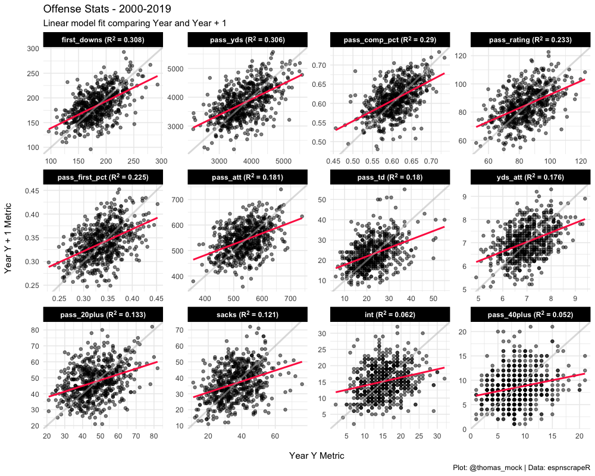

```
(off_plot <- long_off_stats %>%
    inner_join(long_off_stats, by = c("season2" = "season", "team", "metric")) %>%
    mutate(metric = factor(metric,
                           levels = pull(off_stability, metric),
                           labels = pull(off_stability, metric_label))) %>%
    ggplot(aes(x = value.x, y = value.y)) +
    geom_point(color = "black", alpha = 0.5) +
    geom_smooth(method = "lm", color = "#ff2b4f", se = FALSE) +
   scale_x_continuous(breaks = scales::pretty_breaks(n = 5)) +
   scale_y_continuous(breaks = scales::pretty_breaks(n = 5)) +
   geom_abline(intercept = 0, slope = 1, color = "grey", size = 1, alpha = 0.5) +
    facet_wrap(~metric, scales = "free") +
    labs(x = "\nYear Y Metric",
         y = "Year Y + 1 Metric\n",
         title = "Offense Stats - 2000-2019",
         subtitle = "Linear model fit comparing Year and Year + 1",
         caption = "Plot: @thomas_mock | Data: espnscrapeR")  +
    theme_minimal() +
    theme(strip.background = element_rect(fill = "black"),
          strip.text = element_textbox(face = "bold", color = "white")))

# optional output
# ggsave("off_stability_plot.png", off_plot, height = 8, width = 10, dpi = 150)
```